# Building Your First DBSCAN Model

Jie Heng Yu

7/12/2023

# Building Your First DBSCAN Model

For this lesson, we’ll show how to use the DBSCAN algorithm to cluster a data set. We’ll then validate its performance & select the best-performing hyperparameter combination.

### Loading & Exploring the Banknote Data Set

We’re going to work with the Swiss bank not data set to which we applied PCA, t-SNE, & UMAP before. Once we’ve loaded the data set, we convert it into a tibble & create a separate tibble after scaling the data (because DBSCAN & OPTICS) are sensitive to variables scales). Because we’re going to imagine we have no ground truth, we remove the `Status` variable, indicating which banknotes are genuine & which are counterfeit. The tibble contains 200 Swiss banknotes, with 6 measurements of their dimensions.

```r
data(banknote, package = 'mclust')

swissTib <- select(banknote, -Status) %>% as_tibble()
swissTib
```

```
## # A tibble: 200 × 6
##    Length  Left Right Bottom   Top Diagonal
##     <dbl> <dbl> <dbl>  <dbl> <dbl>    <dbl>
##  1   215.  131   131.    9     9.7     141
##  2   215.  130.  130.    8.1   9.5     142.
##  3   215.  130.  130.    8.7   9.6     142.
##  4   215.  130.  130.    7.5  10.4     142
##  5   215   130.  130.   10.4   7.7     142.
##  6   216.  131.  130.    9    10.1     141.
##  7   216.  130.  130.    7.9   9.6     142.
##  8   214.  130.  129.    7.2  10.7     142.
##  9   215.  129.  130.    8.2  11       142.
## 10   215.  130.  130.    9.2  10       141.
## # ℹ 190 more rows
```

```r
swissScaled <- swissTib %>% scale()
```

We’ll plot the data using `ggpairs to remind ourselves of the structure of the data.

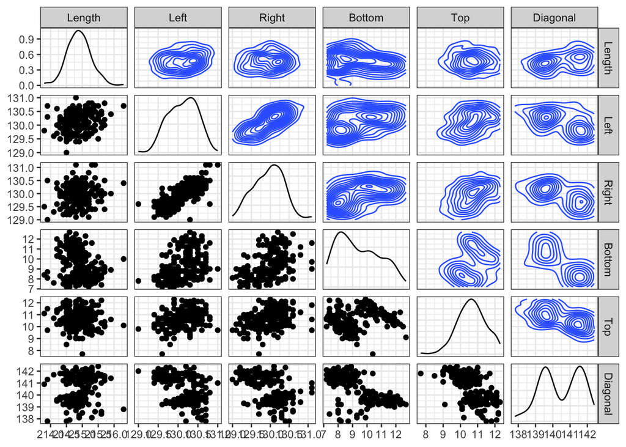

```r
ggpairs(swissTib, upper = list(continuous = 'density')) +
  theme_bw()
```

### Tuning Epsilon & minPts Hyperparameters

Now we’ll show how to select sensible ranges of *epsilon* & *minPts* for DBSCAN, & how we tune them manually to find the best-performing combination. Choosing the value of the *epsilon* hyperparameter is, perhaps, not obvious. How far away from each case should we search? Luckily, there is a heuristic method we can use to at least get in the right ballpark. This consists of calculating the distance from each point to its *k*th-nearest neighbour & then ordering the points in a plot based on this distance. In data with regions of high & low density, this tends to produce a plot containing a ‘knee’ or ‘elbow’. The optimal value of *epsilon* is in or near that knee/elbow. Because a core point in DBSCAN has *minPts* cases inside its *epsilon*, choosing a value of *epsilon* at the kneww of this plot means choosing a search distance that will result in cases in high-density regions being considered core point. We can create this plot using the `kNNdistplot()` function from the dbscan package.

We need to use the *k* argument to specify the number of nearest neighbours we want to calculate the distance to. but we don’t yet know what our *minPts* argument should be, so how can we set k? Usually, we pick a sensible value we believe is approximately correct (recall that *minPts* defines the minimum cluster size); we’ll pick 5. The position of the knee in the plot is relatively robust to changes in k.

We then use the `abline()` function to draw horizaontal lines at the start & end of the knee, to help us identify the range of *epsilon* values we’re going to tune over. The resulting plot is below. Notice that, reading the plot from left to right, after an initial sharp increase, the 5-nearest-neighbour distance increases only gradually, until it rapidly increases again. This region where the curve inflects upward is the knee/elbow, & the optimal value of *epsilon* at this nearest-neighbour distance in this inflection. Using this method, we select 1.2 & 2.0 as the lower & upper limits over which we tune *epsilon*.

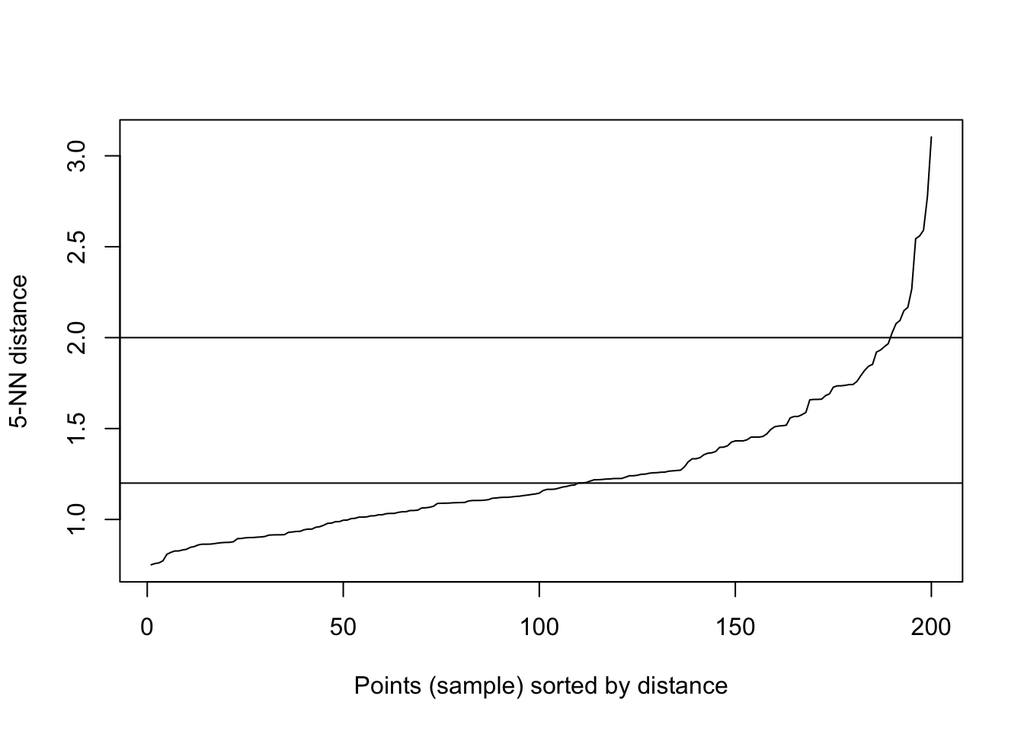

```r
kNNdistplot(swissScaled, k = 5)
abline(h = c(1.2, 2.0))
```

We’ll manually define our hyperparameter search space for *epsilon* & *minPts*. We use the `expand.grid()` function to create a data frame containing every combination of the values of *epsilon* (`eps`) & `minPts` we want to search over. We’re going to search across values of *epsilon* between 1.2 & 2.0, in steps of 0.1;& we’ll search across values of *minPts* between 1 & 9, in steps of 1.

```r
dbsParamSpace <- expand.grid(eps = seq(1.2, 2.0, 0.1),
                             minPts = seq(1, 9, 1))
dbsParamSpace
```

```
##    eps minPts
## 1  1.2      1
## 2  1.3      1
## 3  1.4      1
## 4  1.5      1
## 5  1.6      1
## 6  1.7      1
## 7  1.8      1
## 8  1.9      1
## 9  2.0      1
## 10 1.2      2
## 11 1.3      2
## 12 1.4      2
## 13 1.5      2
## 14 1.6      2
```

[output cut: 67 more lines]

Now that we’ve defined our hyperparameter search space, let’s run the DBSCAN algorithm on each distinct combination of *epsilon* & *minPts*. To do this, we use the `pmap()` function from the purr package to apply the `dbscan()` function to each row of the `dbsParamSpace` object.

```r
swissDbs <- pmap(dbsParamSpace, dbscan, x = swissScaled)
swissDbs[[5]]
```

```
## DBSCAN clustering for 200 objects.
## Parameters: eps = 1.6, minPts = 1
## Using euclidean distances and borderpoints = TRUE
## The clustering contains 10 cluster(s) and 0 noise points.
##
##   1   2   3   4   5   6   7   8   9  10
##   1 189   1   1   1   3   1   1   1   1
##
## Available fields: cluster, eps, minPts, dist, borderPoints
```

We supply our scaled data set as the argument to `dbscan()`’s argument, `x`. The output from `pmap()` is a list where each element is the result of running DBSCAN on that particular combination of *epsilon* & *minPts*. To view the output for a particular permutation, we simply subset the list.

The output, when printing the result of a `dbscan()` call, tells us the number of objects in the data, the values of *epsilon* & *minPts*, & the number of identified clusters & noise points. Perhaps the most important information is the number of cases within each cluster. In this example, we can see there are 189 cases in cluster 2, & just a single case in most of the other clusters. This is because this permutation was run with *minPts* equal to 1, which allows clusters to contain just a single case. This is rarely what we want & will result in a clustering model where no cases are identified as noise.

Now that we have our clustering result, we should visually inspect the clustering to see which (if any) of the permutations give a sensible result. To do this, we want to extract the vector of cluster membership from each permutation as a column & then add these columns to our original data.

The first step is to extract the cluster memberships as separate columns in a tibble. To do this, we use the `map_dfc()` function. We’ve encountered the `map_df()` function before: it applies a function to each element of a vector & returns the output as a tibble, where each output forms a different row of the tibble. This is actually the same as using `map_dfr()`, where the *r* means row-binding. If, instead, we want each output to form a different *column* of the tibble, we use `map_dfc()`.

```r
clusterResults <- map_dfc(swissDbs, ~.$cluster)
clusterResults
```

```
## # A tibble: 200 × 81
##     ...1  ...2  ...3  ...4  ...5  ...6  ...7  ...8  ...9 ...10 ...11 ...12 ...13
##    <int> <int> <int> <int> <int> <int> <int> <int> <int> <int> <int> <int> <int>
##  1     1     1     1     1     1     1     1     1     1     0     0     0     0
##  2     2     2     2     2     2     2     2     2     2     1     1     1     1
##  3     2     2     2     2     2     2     2     2     2     1     1     1     1
##  4     2     2     2     2     2     2     2     2     2     1     1     1     1
##  5     3     3     3     3     3     3     3     3     2     0     0     0     0
##  6     4     4     4     4     4     2     2     2     2     0     0     0     0
##  7     5     2     2     2     2     2     2     2     2     0     1     1     1
##  8     2     2     2     2     2     2     2     2     2     1     1     1     1
##  9     2     2     2     2     2     2     2     2     2     1     1     1     1
## 10     6     2     2     2     2     2     2     2     2     2     1     1     1
## # ℹ 190 more rows
## # ℹ 68 more variables: ...14 <int>, ...15 <int>, ...16 <int>, ...17 <int>,
## #   ...18 <int>, ...19 <int>, ...20 <int>, ...21 <int>, ...22 <int>,
## #   ...23 <int>, ...24 <int>, ...25 <int>, ...26 <int>, ...27 <int>,
## #   ...28 <int>, ...29 <int>, ...30 <int>, ...31 <int>, ...32 <int>,
## #   ...33 <int>, ...34 <int>, ...35 <int>, ...36 <int>, ...37 <int>,
## #   ...38 <int>, ...39 <int>, ...40 <int>, ...41 <int>, ...42 <int>, …
```

Now that we have our tibble of cluster memberships, let’s use the `bind_cols()` function to bind the columns of our `swissTib` tibble & our tibble of cluster memberships. We call this new tibble `swissClusters`, which sounds like a breakfast cereal. Notice that we have our original variables, with additional columns containing the cluster membership output from each permutation.

```r
swissClusters <- bind_cols(swissTib, clusterResults)
swissClusters
```

```
## # A tibble: 200 × 87
##    Length  Left Right Bottom   Top Diagonal  ...7  ...8  ...9 ...10 ...11 ...12
##     <dbl> <dbl> <dbl>  <dbl> <dbl>    <dbl> <int> <int> <int> <int> <int> <int>
##  1   215.  131   131.    9     9.7     141      1     1     1     1     1     1
##  2   215.  130.  130.    8.1   9.5     142.     2     2     2     2     2     2
##  3   215.  130.  130.    8.7   9.6     142.     2     2     2     2     2     2
##  4   215.  130.  130.    7.5  10.4     142      2     2     2     2     2     2
##  5   215   130.  130.   10.4   7.7     142.     3     3     3     3     3     3
##  6   216.  131.  130.    9    10.1     141.     4     4     4     4     4     2
##  7   216.  130.  130.    7.9   9.6     142.     5     2     2     2     2     2
##  8   214.  130.  129.    7.2  10.7     142.     2     2     2     2     2     2
##  9   215.  129.  130.    8.2  11       142.     2     2     2     2     2     2
## 10   215.  130.  130.    9.2  10       141.     6     2     2     2     2     2
## # ℹ 190 more rows
## # ℹ 75 more variables: ...13 <int>, ...14 <int>, ...15 <int>, ...16 <int>,
## #   ...17 <int>, ...18 <int>, ...19 <int>, ...20 <int>, ...21 <int>,
## #   ...22 <int>, ...23 <int>, ...24 <int>, ...25 <int>, ...26 <int>,
## #   ...27 <int>, ...28 <int>, ...29 <int>, ...30 <int>, ...31 <int>,
## #   ...32 <int>, ...33 <int>, ...34 <int>, ...35 <int>, ...36 <int>,
## #   ...37 <int>, ...38 <int>, ...39 <int>, ...40 <int>, ...41 <int>, …
```

In order to plot the results, we would like to facet by permutation so we can draw a separate subplot for each combination of our hyperparameters. To do this, we need to `gather()` the data to create a new column indicating permutation number & another column indicating the cluster number.

```r
swissClustersGathered <- gather(swissClusters,
                                key = 'Permutation', value = 'Cluster',
                                -Length, -Left, -Right,
                                -Bottom, -Top, -Diagonal)
swissClustersGathered
```

```
## # A tibble: 16,200 × 8
##    Length  Left Right Bottom   Top Diagonal Permutation Cluster
##     <dbl> <dbl> <dbl>  <dbl> <dbl>    <dbl> <chr>         <int>
##  1   215.  131   131.    9     9.7     141  ...7              1
##  2   215.  130.  130.    8.1   9.5     142. ...7              2
##  3   215.  130.  130.    8.7   9.6     142. ...7              2
##  4   215.  130.  130.    7.5  10.4     142  ...7              2
##  5   215   130.  130.   10.4   7.7     142. ...7              3
##  6   216.  131.  130.    9    10.1     141. ...7              4
##  7   216.  130.  130.    7.9   9.6     142. ...7              5
##  8   214.  130.  129.    7.2  10.7     142. ...7              2
##  9   215.  129.  130.    8.2  11       142. ...7              2
## 10   215.  130.  130.    9.2  10       141. ...7              6
## # ℹ 16,190 more rows
```

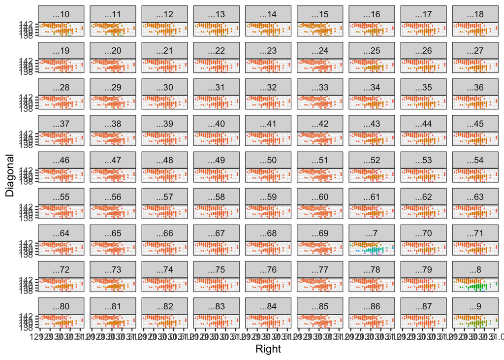

```r
ggplot(swissClustersGathered, aes(Right, Diagonal,
                                  col = as.factor(Cluster))) +
  facet_wrap(~ Permutation) +
  geom_point(size = 0.05) +
  theme_bw() +
  theme(legend.position = 'none')
```

How are we going to choose the best-performing combination of *epsilon* & *minPts*? Visually checking to make sure the clusters are sensible is important, but we can calculate internal cluster metrics to help guide our choice.

```r
cluster_metrics <- function(data, clusters, dist_matrix) {
  list(db = clusterSim::index.DB(data, clusters)$DB,
       G1 = clusterSim::index.G1(data, clusters),
       dunn = clValid::dunn(dist_matrix, clusters),
       clusters = length(unique(clusters)))
}
```